# Estudios de Informática, Multimedia y Telecomunicaciones

# Minería de datos: PEC3 - Clasificación con árboles de decisión

Autor: Nombre estudiante

Diciembre 2023

Enunciado del ejercicio

Para el conjunto de datos German Credit, los alumnos deben completar aquí la solución a la PEC3 que consiste de los siguientes apartados. Notad que se detalla el contenido necesario para cada apartado en la Sección 4 (Rúbrica).

El formato de entrega es como en las anteriores PECs: **usernameestudiant-PECn.html** (o PDF/Word) y el código **Rmd**.

Se debe entregar la PEC en el buzón de entregas del aula, como en las anteriores PECs.

# 1 EJERCICIO 1

Realizar un primer análisis descriptivo y de correlaciones. Es importante en este apartado entender bien los datos antes de seguir con los análisis posteriores. Lista todo lo que te haya sorprendido de los datos

## 1.1 PRESENTACIÓN DEL CASO

### 1.1.1 FUENTE DE LOS DATOS

https://www.kaggle.com/shravan3273/credit-approval

### 1.1.2 DESCRIPCIÓN DE LOS DATOS

El conjunto de datos a estudiar nos muestra los criterios que las diferentes entidades financieras alemanas aplican a la hora de conceder o no un crédito a aquellos que lo deseen.

### 1.1.3 OBJETIVO ANALÍTICO

El objetivo analítico será averiguar mediante un estudio preeliminar cuales son los factores que más influyen a la hora de recibir un crédito.

### 1.1.4 METODOLOGÍA

El enfoque de trabajo estará basado en los procesos CRISPDM. Por otro lado, la técnica de análisis a emplear será el estudio de correlaciones PCA y la observación holística de los datos.

### 1.1.5 LIBRERÍAS

Las librearías a emplear son las siguientes:

```r
if (!require("dplyr")) install.packages("dplyr");
library('dplyr')

if (!require('ggplot2')) install.packages('ggplot2');
library('ggplot2')

if (!require("tidyr")) install.packages("tidyr");
library('tidyr')

if (!require('factoextra')) install.packages('factoextra');
library('factoextra')

if (!require('corrplot')) install.packages('corrplot');
library('corrplot')

if (!require('correlation')) install.packages('correlation');
library(correlation)
```

## 1.2 GESTIÓN Y PROCESAMIENTO DE LOS DATOS Y CARACTERÍSTICAS

### 1.2.1 EL CONJUNTO DE DATOS

#### 1.2.1.1 CARGA DE DATOS

```r
conjunto_datos <- read.csv("./data/credit-2.csv", header = TRUE)
```

#### 1.2.1.2 ESTRUCTURA GENERAL

Verificamos la estructura del juego de datos a partir del número de columnas que tenemos y de los ejemplos de los contenidos de las filas:

```r
str(conjunto_datos)
```

```
## 'data.frame':    1000 obs. of  21 variables:
##  $ checking_balance    : chr  "< 0 DM" "1 - 200 DM" "unknown" "< 0 DM" ...
##  $ months_loan_duration: int  6 48 12 42 24 36 24 36 12 30 ...
##  $ credit_history      : chr  "critical" "repaid" "critical" "repaid" ...
##  $ purpose             : chr  "radio/tv" "radio/tv" "education" "furniture" ...
##  $ amount              : int  1169 5951 2096 7882 4870 9055 2835 6948 3059 5234 ...
##  $ savings_balance     : chr  "unknown" "< 100 DM" "< 100 DM" "< 100 DM" ...
##  $ employment_length   : chr  "> 7 yrs" "1 - 4 yrs" "4 - 7 yrs" "4 - 7 yrs" ...
##  $ installment_rate    : int  4 2 2 2 3 2 3 2 2 4 ...
##  $ personal_status     : chr  "single male" "female" "single male" "single male" ...
##  $ other_debtors       : chr  "none" "none" "none" "guarantor" ...
##  $ residence_history   : int  4 2 3 4 4 4 4 2 4 2 ...
##  $ property            : chr  "real estate" "real estate" "real estate" "building society savings" ...
##  $ age                 : int  67 22 49 45 53 35 53 35 61 28 ...
##  $ installment_plan    : chr  "none" "none" "none" "none" ...
##  $ housing             : chr  "own" "own" "own" "for free" ...
##  $ existing_credits    : int  2 1 1 1 2 1 1 1 1 2 ...
##  $ default             : int  1 2 1 1 2 1 1 1 1 2 ...
##  $ dependents          : int  1 1 2 2 2 2 1 1 1 1 ...
##  $ telephone           : chr  "yes" "none" "none" "none" ...
##  $ foreign_worker      : chr  "yes" "yes" "yes" "yes" ...
##  $ job                 : chr  "skilled employee" "skilled employee" "unskilled resident" "skilled employee" ...
```

El conjunto de datos contiene **21** variables y **1000** registros.

#### 1.2.1.3 DICCIONARIO DE VARIABLES

Revisaremos la descripción de las variables y sus tipos, luego, las organizaremos lógicamente para darles sentido con el objetivo de construir un diccionario de variables:

```r
str(conjunto_datos)
```

```
## 'data.frame':    1000 obs. of  21 variables:
##  $ checking_balance    : chr  "< 0 DM" "1 - 200 DM" "unknown" "< 0 DM" ...
##  $ months_loan_duration: int  6 48 12 42 24 36 24 36 12 30 ...
##  $ credit_history      : chr  "critical" "repaid" "critical" "repaid" ...
##  $ purpose             : chr  "radio/tv" "radio/tv" "education" "furniture" ...
##  $ amount              : int  1169 5951 2096 7882 4870 9055 2835 6948 3059 5234 ...
##  $ savings_balance     : chr  "unknown" "< 100 DM" "< 100 DM" "< 100 DM" ...
##  $ employment_length   : chr  "> 7 yrs" "1 - 4 yrs" "4 - 7 yrs" "4 - 7 yrs" ...
##  $ installment_rate    : int  4 2 2 2 3 2 3 2 2 4 ...
##  $ personal_status     : chr  "single male" "female" "single male" "single male" ...
##  $ other_debtors       : chr  "none" "none" "none" "guarantor" ...
##  $ residence_history   : int  4 2 3 4 4 4 4 2 4 2 ...
##  $ property            : chr  "real estate" "real estate" "real estate" "building society savings" ...
##  $ age                 : int  67 22 49 45 53 35 53 35 61 28 ...
##  $ installment_plan    : chr  "none" "none" "none" "none" ...
##  $ housing             : chr  "own" "own" "own" "for free" ...
##  $ existing_credits    : int  2 1 1 1 2 1 1 1 1 2 ...
##  $ default             : int  1 2 1 1 2 1 1 1 1 2 ...
##  $ dependents          : int  1 1 2 2 2 2 1 1 1 1 ...
##  $ telephone           : chr  "yes" "none" "none" "none" ...
##  $ foreign_worker      : chr  "yes" "yes" "yes" "yes" ...
##  $ job                 : chr  "skilled employee" "skilled employee" "unskilled resident" "skilled employee" ...
```

##### 1.2.1.3.1 VARIABLES RELACIONADAS CON EL PRESTAMO

**purpose (chr)** - Finalidad del préstamo  
**amount (int)** - Cantidad del préstamo, en Marco Alemán  
**months_loan_duration (int)** - Duración del préstamo, en meses

##### 1.2.1.3.2 VARIABLES RELACIONADAS CON EL PRESTATARIO

**checking_balance (chr)** - Cantidad de dinero en la cuenta del prestatario, en Marco Alemán  
**credit_history (chr)** - Registro del reembolso responsable de las deudas por parte de un prestatario.  
**savings_balance (chr)** - Ahorros del prestatario, en Marco Alemán  
**employment_length (chr)** - Tiempo que lleva empleado el prestatario, en años  
**installment_rate (int)** - Cantidad de dinero pagada por unidad de tiempo, en Marco Alemán al mes (?)  
**personal_status (chr)** - Género y estado matrimonial del prestatario  
**other_debtors (chr)** - Descripción de otros prestatario que forman parte del mismo préstamo, si los hay  
**residence_history (int)** - Tiempo de residencia del prestatario, expresado en años  
**property (chr)** - Propiedad del prestatario  
**age (int)** - Edad del prestatario  
**installment_plan (chr)** - Descripción del plan de pago a plazos del prestatario  
**housing (chr)** - Vivienda del prestatario  
**existing_credits (int)** - Número de créditos que debe el prestatario  
**default (int)** - Veces que el prestatario no ha realizado el pagamiento de la deuda  
**dependents (int)** - Número de personas que dependen del prestatario  
**telephone (chr)** - Si el prestatario tiene o no teléfono  
**foreign_worker (chr)** - Si el prestatario es trabajador extranjero  
**job (chr)** - Tipo de empleo del prestatario

#### 1.2.1.4 DISTRIBUCIÓN GENERAL DE LOS DATOS

##### 1.2.1.4.1 HISTOGRAMAS

Una vez sabemos que datos hacen referencia cada variable, se comprobará el estado de los registros del conjunto de datos para estudiar como proceder con el tratamiento. Para ello, se visualizarán los datos mediante histogramas.

```r
histList<- list()

for(y in 1:ncol(conjunto_datos)){

  col <- names(conjunto_datos)[y]
  ggp <- ggplot(conjunto_datos[y], aes_string(x = col)) +
         geom_bar(aes(y = (..count..)/sum(..count..))) +
        ylab("distribution")

  histList[[y]] <- ggp
}
```

Los histogramas obtenidos son los siguientes:

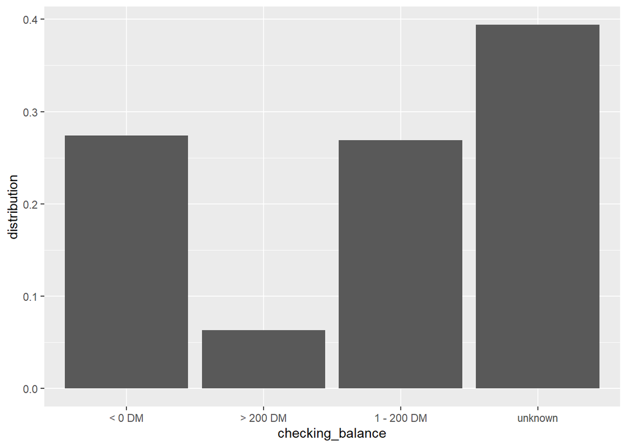

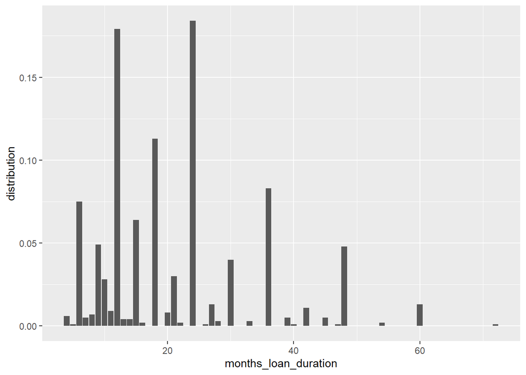

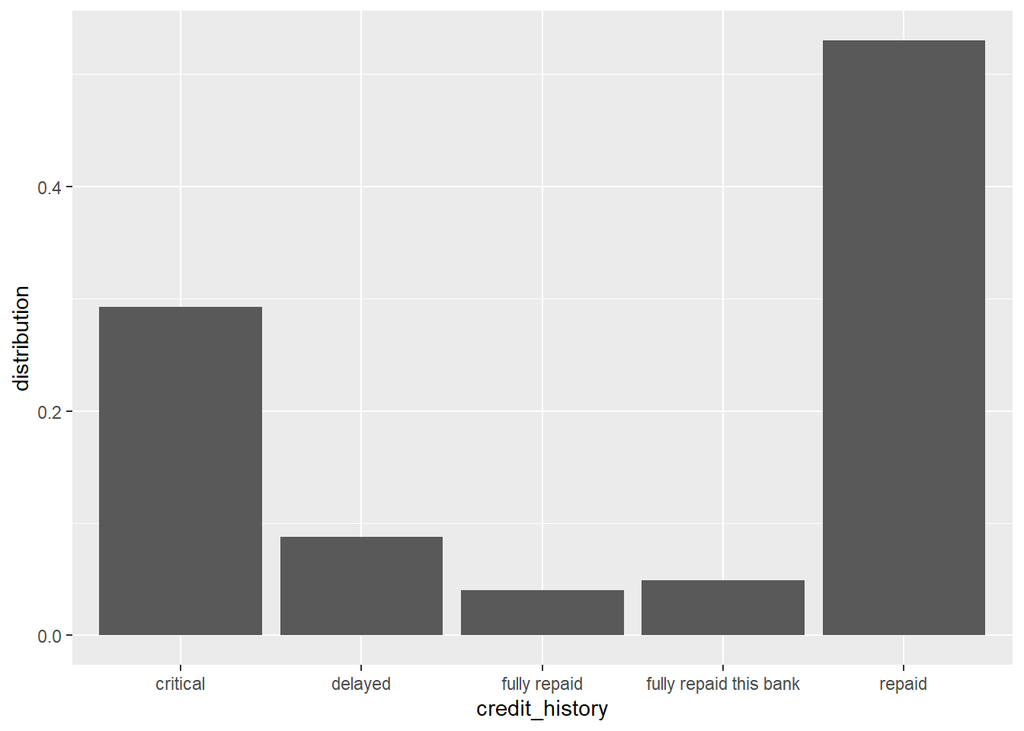

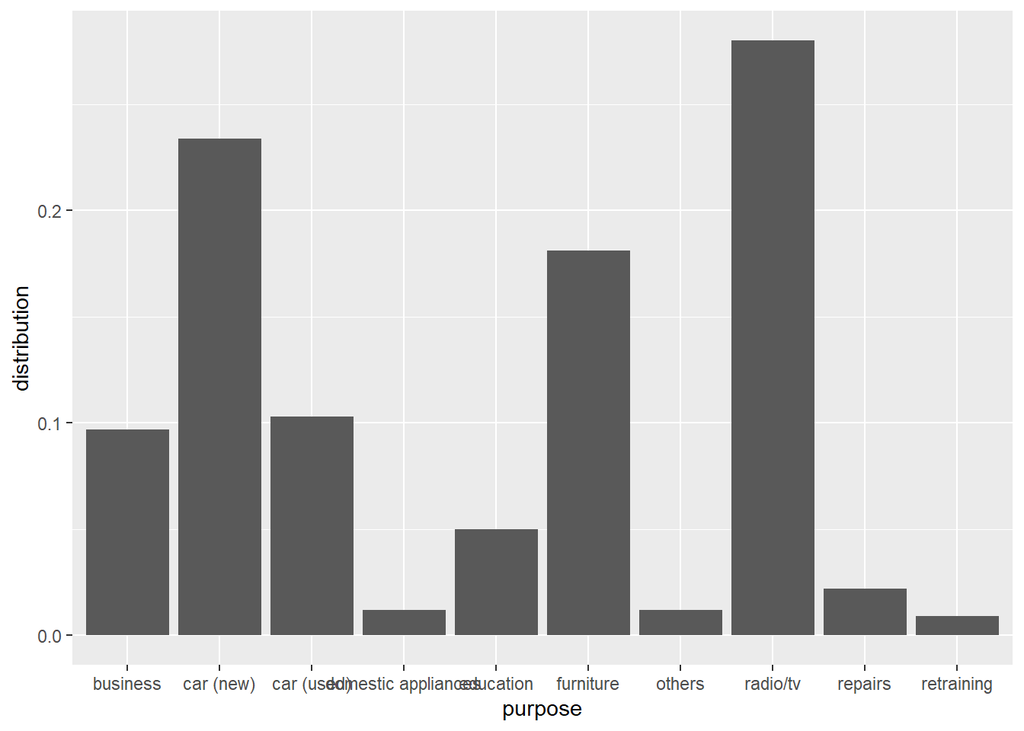

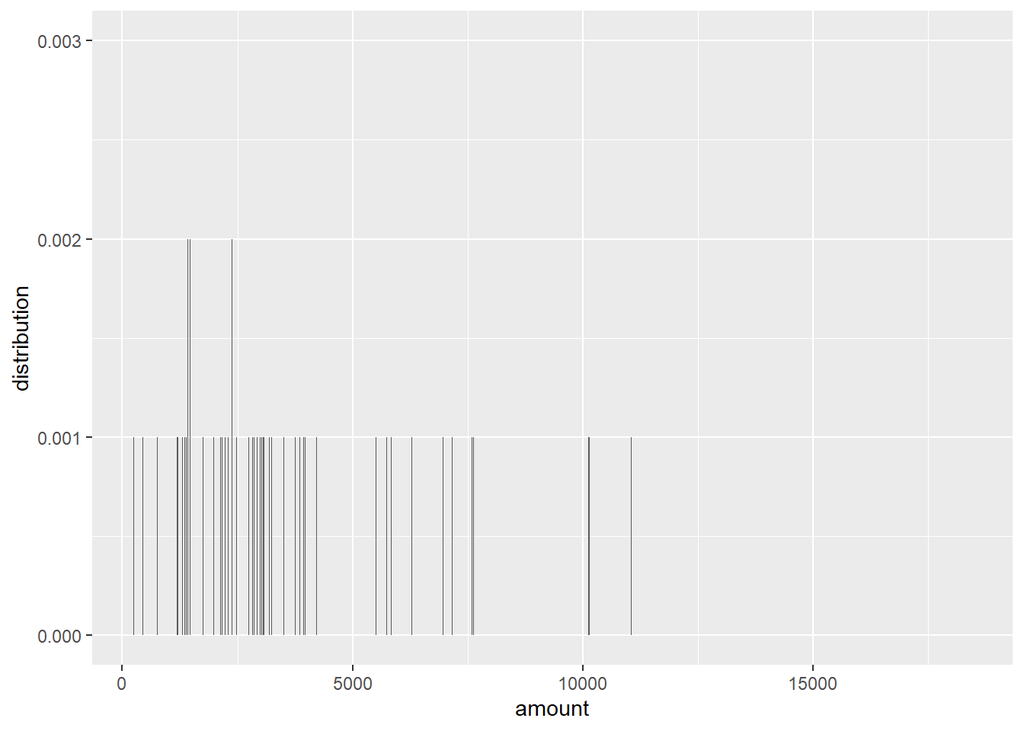

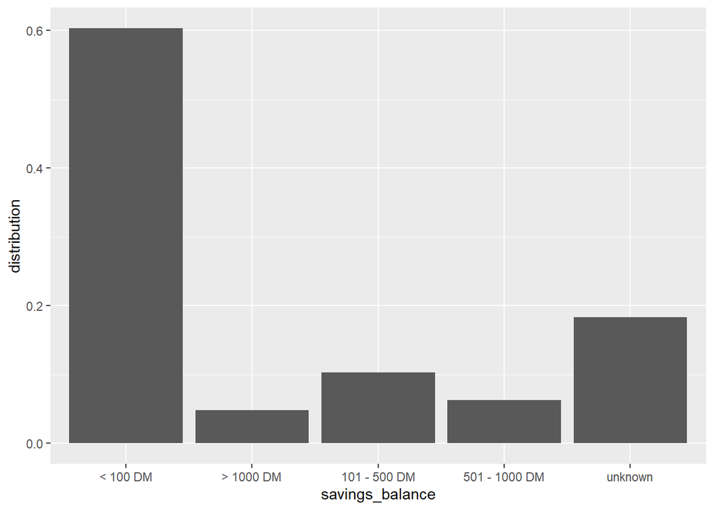

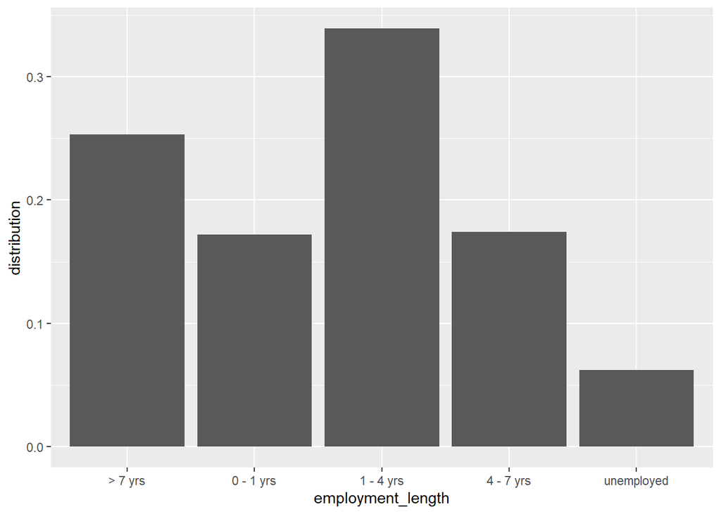

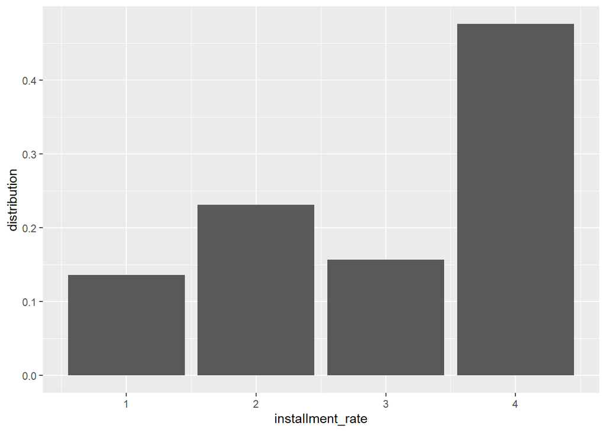

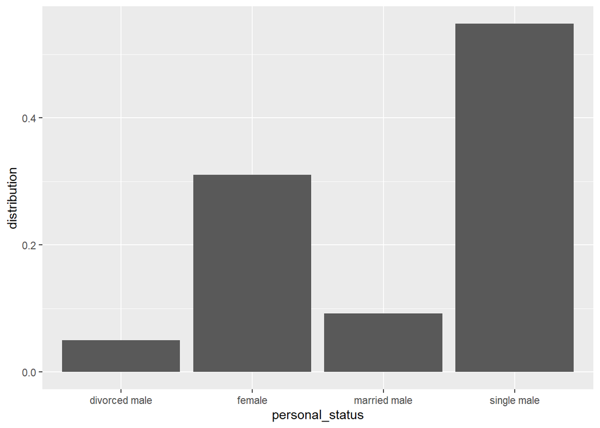

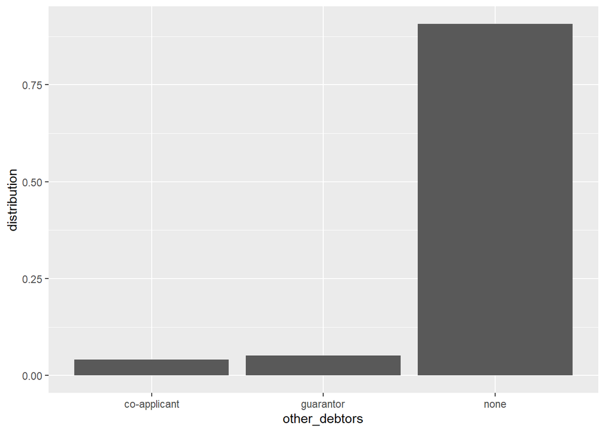

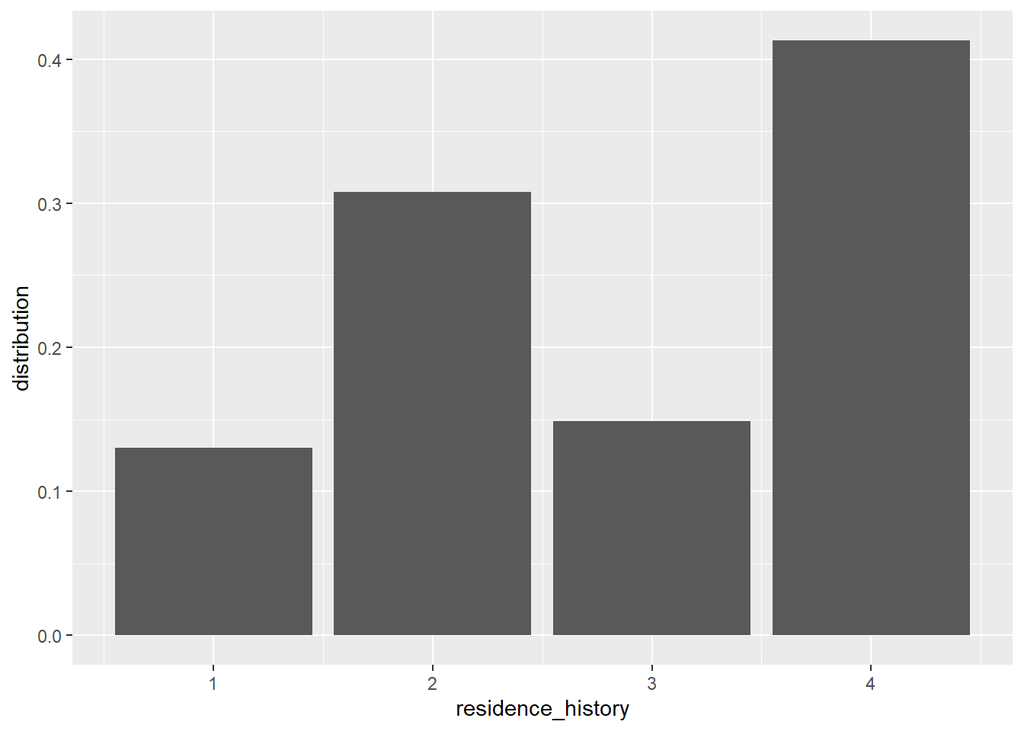

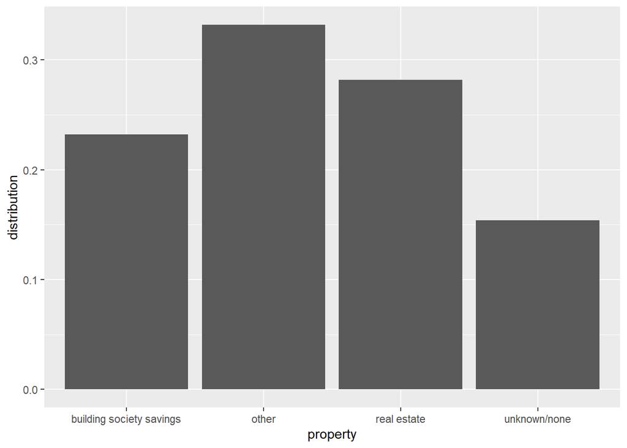

[9 more figures not shown]

```r
histList[1:ncol(conjunto_datos)]
```

Se observa que la mayoría de variables son de tipo categórico y los datos almacenados son trabajables.

##### 1.2.1.4.2 OBSERVACIONES

###### 1.2.1.4.2.1 OBSERVACIONES GLOBALES

Se observa que hay variables categóricas y contiguas. Deberemos transformarlas todas en categóricas más adelante para poder aplicar correctamente modelos.

Además, diversas variables presentan datos difíciles de analizar debido a la falta de información adicional.

###### 1.2.1.4.2.2 OBSERVACIONES ESPECÍFICAS

**checking_balance**

Aproximadamente el 40% de los datos son desconocidos. Se procederá ignorando esta observación.

Además, categorías desordenadas que podrían perturbar un futuro análisis, especificamente la categoría “> 200 DM”.

**savings_balance**

Presenta categorías desordenadas que podrían perturbar un futuro análisis, especificamente la categoría “> 1000 DM”.

**employment_length**

Presenta categorías desordenadas que podrían perturbar un futuro análisis, especificamente las categorías “>7 years” y “unemployed”.

**credit_history**

Presenta datos que podrían ser mejor explicados a partir de la derivación de una nueva variable: **credit_repaired**, compuesta por las categorías “yes” y “no”.

**purpose**

Presenta datos que podrían ser mejor explicados a partir de la derivación de una nueva variable: **purpose_category**, compuesta por las categorías “investment”, “amenities” y “car”, conservando “others”.

**installment_rate**

Presenta datos que no son posibles analizar, pues carecen de contexto o unidad métrica.

Especificamente, no sabemos si se trata de categorías o valores nominales y, en caso de ser categorías, a que hacen referencia.

**installment_plan**

Presenta datos que podrían ser mejor explicados a partir de la derivación de una nueva variable: **has_installment_plan**, compuesta por las categorías “yes” y “no”.

**personal_status**

Presenta datos incompletos, pues no sabemos el estado matrimonial de las mujeres.

Debido a esto, presenta datos que podrían ser mejor explicados a partir de la derivación de una nueva variable:**gender**, compuesta por las categorías “male” y “female”

**other_debtors**

Presenta datos que podrían ser mejor explicados a partir de la derivación de una nueva variable: **has_other_debtors**, compuesta por las categorías “yes” y “no”.

**residence_history**

Presenta datos que no son posibles analizar, pues carecen de contexto o unidad métrica.

Especificamente, no sabemos si se trata de categorías o valores nominales y, en caso de ser categorías, a que hacen referencia

**default**

Presenta datos que no son posibles analizar, pues carecen de contexto o unidad métrica.

Específicamente, no es posible saber si la variables es binaria o numérica. En el caso de que fuera binaria, no se sabe que valor corresponde afirmativamente o negativamente.

**dependents**

Presenta datos que no son posibles analizar, pues carecen de contexto o unidad métrica.

Específicamente, no es posible saber si la variables es binaria o numérica. En el caso de que fuera binaria, no se sabe que valor corresponde afirmativamente o negativamente.

**job**

Presenta datos que no son posibles analizar correctamente, pues carecen de precisión y contexto común.

Específicamente, se listan como categorias “unskilled resident” y “skilled employee”, las cuales no nos proporcionan la suficiente información (es “skilled employee” residente o no?, el “unskilled resident” trabaja actualmente o no?, etc…)

### 1.2.2 TRATAMIENTO DEL CONJUNTO DE DATOS

Una vez hemos observado la distribución de los datos, podemos saber como tratar los datos para poder aplicar en el futuro modelos de clasificación.

#### 1.2.2.1 MODIFICACIÓN DE DATOS

##### 1.2.2.1.1 LIMPIEZA DE DATOS

Se eliminarán aquellos registros que impiden un correcto estudio de los datos.

###### 1.2.2.1.1.1 DATOS VACÍOS

Se comprobará si el conjunto de datos presenta valores vacíos:

```r
colSums(conjunto_datos=="")
```

```
##     checking_balance months_loan_duration       credit_history
##                    0                    0                    0
##              purpose               amount      savings_balance
##                    0                    0                    0
##    employment_length     installment_rate      personal_status
##                    0                    0                    0
##        other_debtors    residence_history             property
##                    0                    0                    0
##                  age     installment_plan              housing
##                    0                    0                    0
##     existing_credits              default           dependents
##                    0                    0                    0
##            telephone       foreign_worker                  job
##                    0                    0                    0
```

El conjunto no presenta datos vacíos, por lo que no se eliminarán registros.

###### 1.2.2.1.1.2 DATOS NULOS

Se comprobará si el conjunto de datos presenta valores nulos:

```r
colSums(is.na(conjunto_datos))
```

```
##     checking_balance months_loan_duration       credit_history
##                    0                    0                    0
##              purpose               amount      savings_balance
##                    0                    0                    0
##    employment_length     installment_rate      personal_status
##                    0                    0                    0
##        other_debtors    residence_history             property
##                    0                    0                    0
##                  age     installment_plan              housing
##                    0                    0                    0
##     existing_credits              default           dependents
##                    0                    0                    0
##            telephone       foreign_worker                  job
##                    0                    0                    0
```

El conjunto no presenta datos nulos, por lo que no se eliminarán registros.

###### 1.2.2.1.1.3 DATOS REPETIDOS

Se comprobará si el conjunto de datos presenta valores repetidos:

```r
count(distinct(conjunto_datos))
```

```
##      n
## 1 1000
```

El conjunto no presenta datos repetidos, por lo que no se eliminarán registros.

##### 1.2.2.1.2 TRANSFORMACIÓN DE LOS DATOS

Una vez hemos eliminado aquellos registros que pueden potencialmente interferir con nuestro modelo, pasaremos a transformar aquellas variables y registros en un formato estudiable. Para ello, todos los datos serán discretizados y, aquellos que ya lo están, serán expresados en dígitos.

Antes de realizar la tarea, se realizará una copia de los datos originales y se trabajará a partir de ésta:

```r
conjunto_datos_original <- conjunto_datos
```

###### 1.2.2.1.2.1 DISCRETIZACIÓN DE LAS VARIABLES CONTÍNUAS

El primer paso será determinar cuales son aquellas variables contínuas que debemos discretizar:

```r
numList <- list()
x <- 1

for(y in 2:ncol(conjunto_datos)){

  if(is.numeric(conjunto_datos[, y])){
    numList[[x]] <- names(conjunto_datos)[y]
    x <- x+1
  }

}

for(y in numList){
  print(y)
}
```

```
## [1] "months_loan_duration"
## [1] "amount"
## [1] "installment_rate"
## [1] "residence_history"
## [1] "age"
## [1] "existing_credits"
## [1] "default"
## [1] "dependents"
```

Una vez obtenidas, pasaremos a realizar categorías para cada una de ellas en función de la distribución de datos que presentan.

Histogramas:

```
##  months_loan_duration
##  Min.   : 4.0
##  1st Qu.:12.0
##  Median :18.0
##  Mean   :20.9
##  3rd Qu.:24.0
##  Max.   :72.0
```

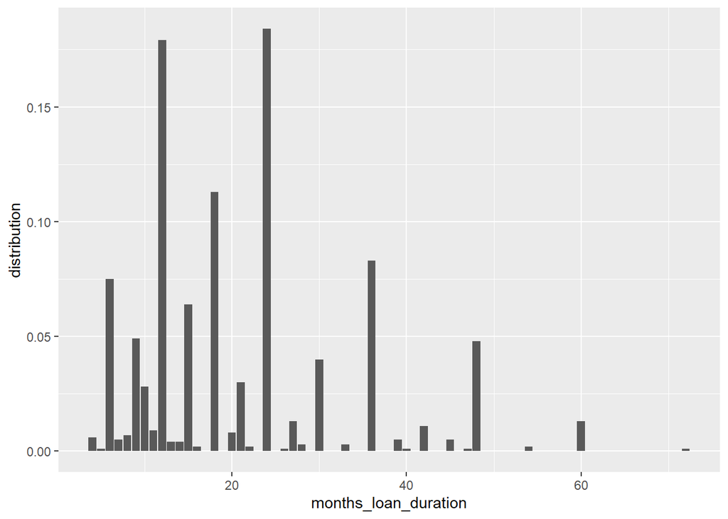

```
##      amount
##  Min.   :  250
##  1st Qu.: 1366
##  Median : 2320
##  Mean   : 3271
##  3rd Qu.: 3972
##  Max.   :18424
```

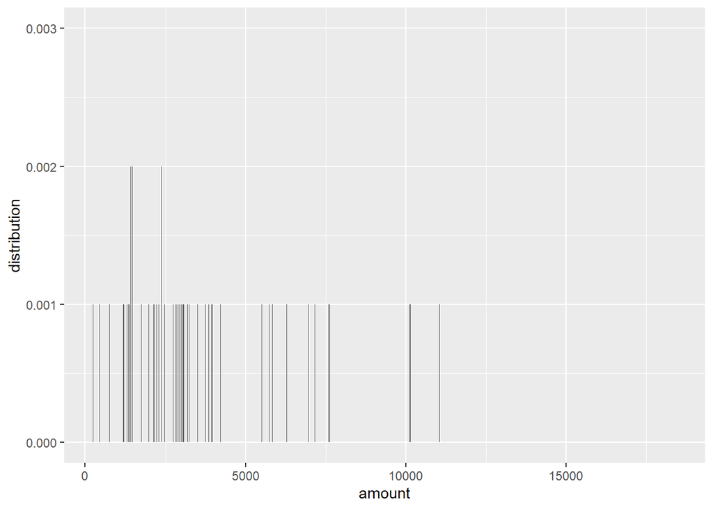

```
##  installment_rate
##  Min.   :1.000
##  1st Qu.:2.000
##  Median :3.000
##  Mean   :2.973
##  3rd Qu.:4.000
##  Max.   :4.000
```

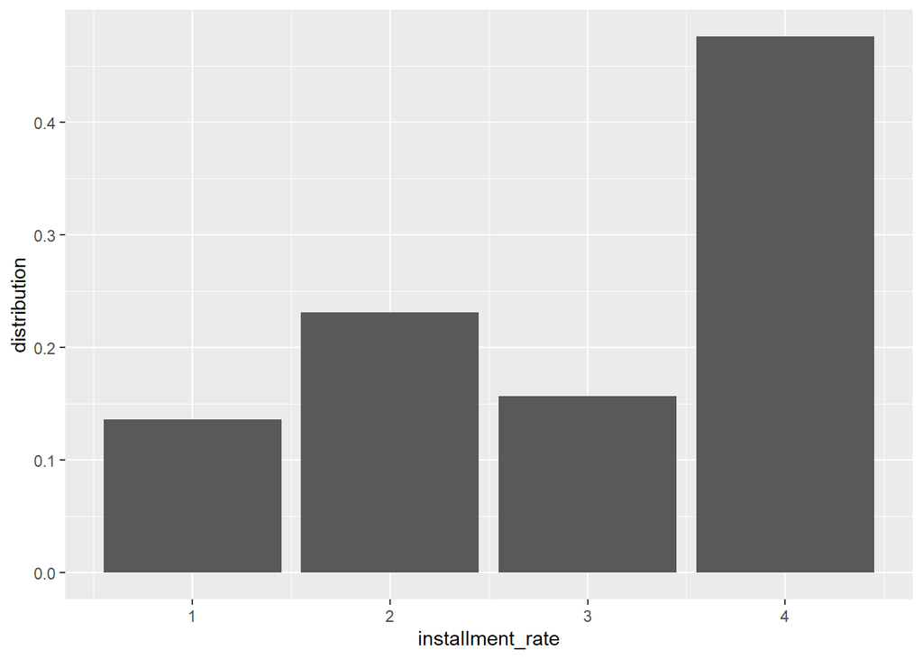

```
##  residence_history
##  Min.   :1.000
##  1st Qu.:2.000
##  Median :3.000
##  Mean   :2.845
##  3rd Qu.:4.000
##  Max.   :4.000
```

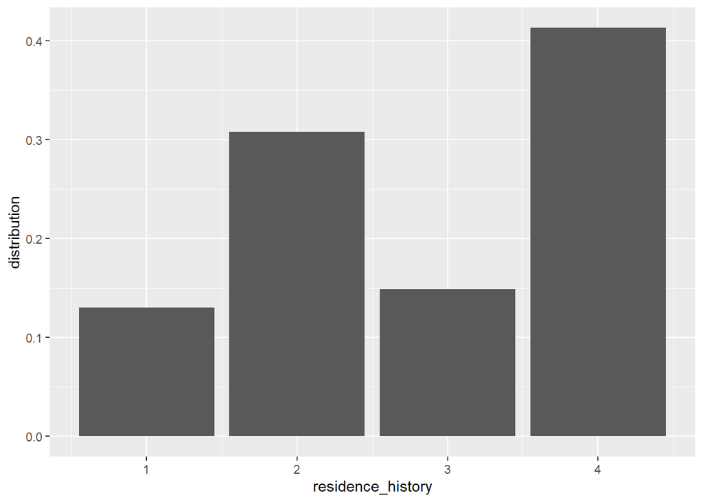

```
##       age
##  Min.   :19.00
##  1st Qu.:27.00
##  Median :33.00
##  Mean   :35.55
##  3rd Qu.:42.00
##  Max.   :75.00
```

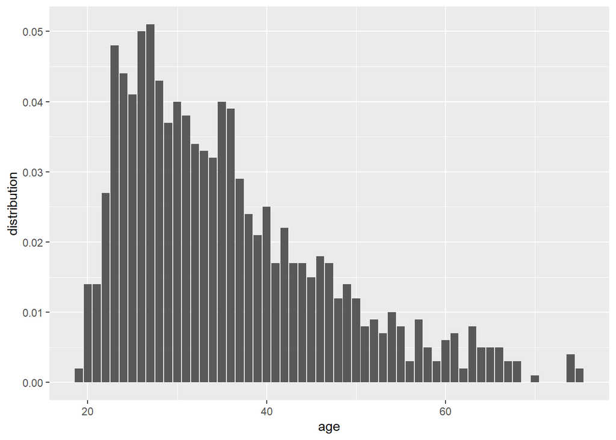

```
##  existing_credits
##  Min.   :1.000
##  1st Qu.:1.000
##  Median :1.000
##  Mean   :1.407
##  3rd Qu.:2.000
##  Max.   :4.000
```

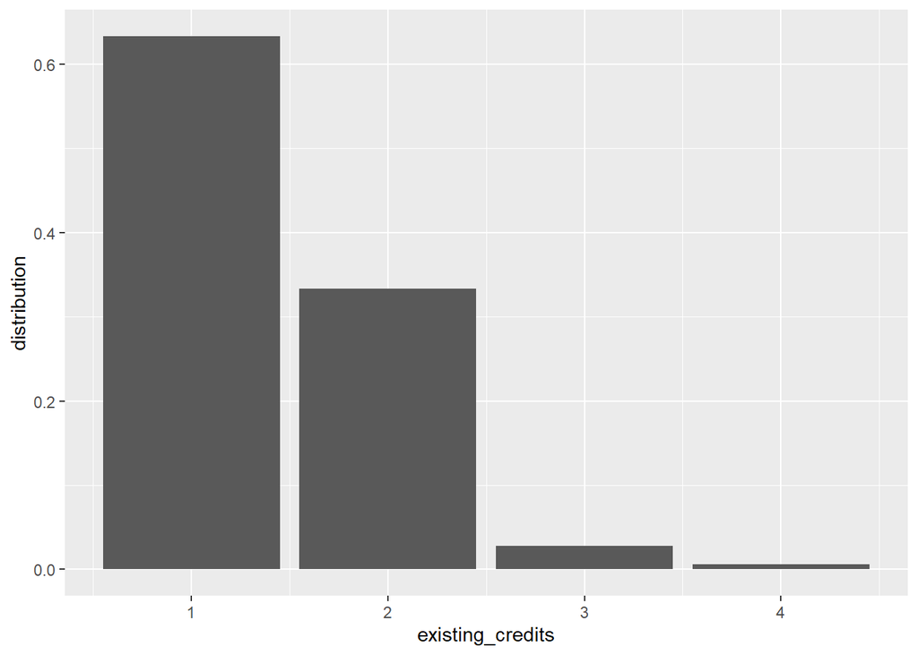

```
##     default
##  Min.   :1.0
##  1st Qu.:1.0
##  Median :1.0
##  Mean   :1.3
##  3rd Qu.:2.0
##  Max.   :2.0
```

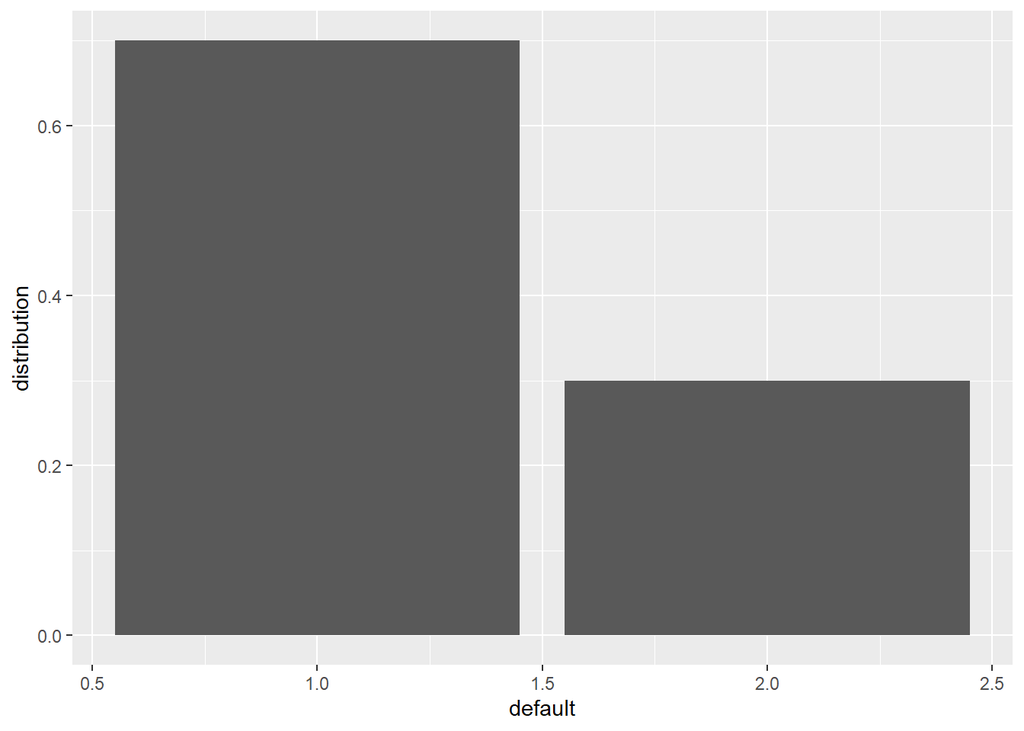

```
##    dependents
##  Min.   :1.000
##  1st Qu.:1.000
##  Median :1.000
##  Mean   :1.155
##  3rd Qu.:1.000
##  Max.   :2.000
```

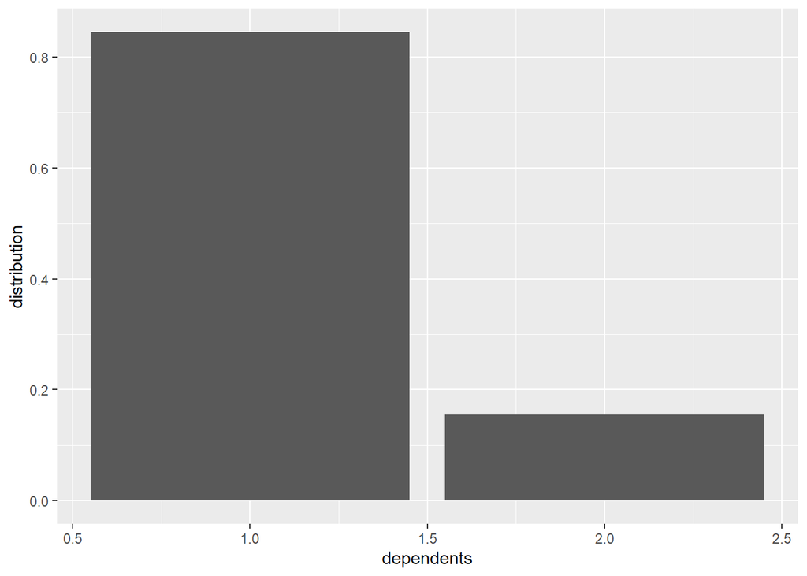

```r
for(y in numList){
  #summary
  print(summary(conjunto_datos[y]))
  #plot
  ggp <- ggplot(conjunto_datos[y], aes_string(x = y)) +
         geom_bar(aes(y = (..count..)/sum(..count..))) +
        ylab("distribution")
  print(ggp)
}
```

**months_loan_duration**

-Categorías a crear

La categorías se basarán en los cuartiles y son las siguientes:

1 = Menos de 12  
2 = Entre 12 y 18  
3 = Entre 18 y 24  
4 = Más de 24

-Código

```r
conjunto_datos <- mutate(conjunto_datos, months_loan_duration =
                          ifelse(months_loan_duration<12, 1,
                                 ifelse(months_loan_duration<18, 2,
                                        ifelse(months_loan_duration<24, 3, 4)
                                        )
                                )
)
```

-Resultado

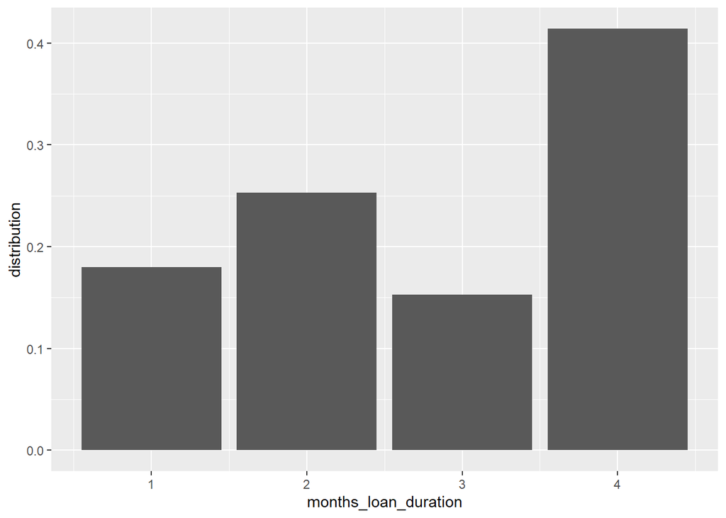

```r
ggp <- ggplot(conjunto_datos["months_loan_duration"], aes_string(x = "months_loan_duration")) +
      geom_bar(aes(y = (..count..)/sum(..count..))) + ylab("distribution")
ggp
```

**amount**

-Categorías a crear

-Código

```r
conjunto_datos <- mutate(conjunto_datos, amount =
                          ifelse(amount<1366, 1, 2
                                )
)
```

```r
#conjunto_datos <- mutate(conjunto_datos, amount =
#                          ifelse(amount<1366, 1,
#                                 ifelse(amount<2320, 2,
#                                        ifelse(amount<3972, 3, 4)
#                                        )
#                                )
#)
```

-Resultado

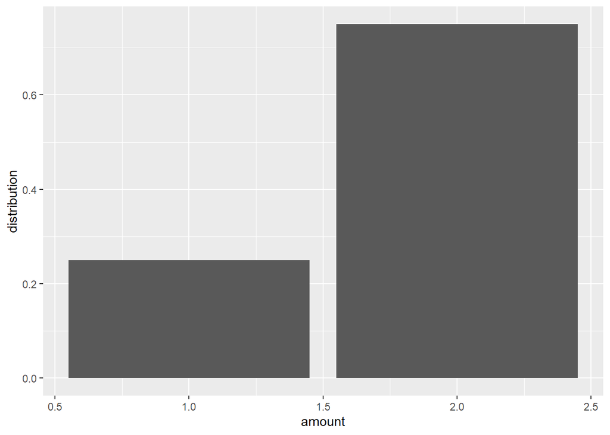

```r
ggp <- ggplot(conjunto_datos["amount"], aes_string(x = "amount")) +
      geom_bar(aes(y = (..count..)/sum(..count..))) + ylab("distribution")
ggp
```

**age**

-Categorías a crear

La categorías se basarán en los cuartiles y son las siguientes:

1 = Menos de 27 2 = Entre 27 y 33 3 = Entre 33 y 42 4 = Más de 42

-Código

```r
conjunto_datos <- mutate(conjunto_datos, age =
                          ifelse(age<27, 1,
                                 ifelse(age<33, 2,
                                        ifelse(age<42, 3, 4)
                                        )
                                )
)
```

-Resultado

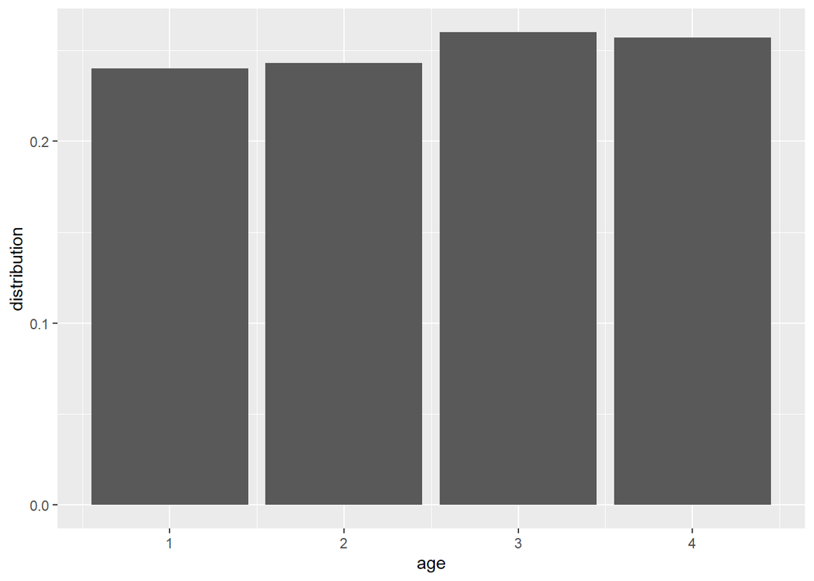

```r
ggp <- ggplot(conjunto_datos["age"], aes_string(x = "age")) +
      geom_bar(aes(y = (..count..)/sum(..count..))) + ylab("distribution")
ggp
```

**installment_rate**, **residence_history**, **existing_credits**, **default**, **dependents**

Las variables mencionadas, a pesar de ser numéricas, son categóricas y no serán transformadas.

###### 1.2.2.1.2.2 CONVERSIÓN DE LAS CATEGORÍAS EXPRESADAS EN TEXTO A DÍGITO

Variables categóricas que expresaremos en dígitos mediante factorización:

```r
if (!require("dplyr")) install.packages("dplyr");
library('dplyr')

categoriesList <- list()
x <- 1

for(y in 1:ncol(conjunto_datos)){
  if(is.character(conjunto_datos[, y])){

    categoriesList[[x]] <- names(conjunto_datos)[y]
    conjunto_datos[, y] <- as.numeric(factor(conjunto_datos[, y]))

    x <- x+1

  }
}

for(y in categoriesList){
  print(y)
}
```

```
## [1] "checking_balance"
## [1] "credit_history"
## [1] "purpose"
## [1] "savings_balance"
## [1] "employment_length"
## [1] "personal_status"
## [1] "other_debtors"
## [1] "property"
## [1] "installment_plan"
## [1] "housing"
## [1] "telephone"
## [1] "foreign_worker"
## [1] "job"
```